# Talent_Management

Tanvi Arora, Rebecca Holsapple, Anjli Solsi, Anne Francomano

July 23, 2018

### Introduction

TARA Pharma Corp. (TARA), headquartered in Seattle, WA, develops, manufactures and markets a range of dietary supplement product lines. With 4,000 employees and 2 billion USD (FY 2017) in revenue, it must maintain its global brand integrity and continue its financial growth. Doing so depends on attracting and retaining great talent. Players in the Seattle pharmaceutical industry face stiff competition for new hires, and the fact that it is not uncommon for some local firms to entice away their competitors’ current employees makes it even more challenging.

To gain a competitive edge over its rivals, TARA is evaluating the role a data science approach to talent management could play as part of its overall business strategy. TARA’s CIO and team have proposed an analytics-centric talent management initiative, which, like all proposals, is subject to a proof-of-concept analysis before it can be presented to the TARA executive managment team for consideration/approval.

TARA’s CIO has contracted DDS Analytics to conduct the proof-of-concept analysis as part of evaluating the intiative. The proof-of-concept analysis aims to illustrate how applying data analytics to employee data would provide insight for employee retention and in turn contribute to the justification for investing in the initiative.

TARA management suspects that the attrition rate is too high for its top-performing employees in the Human Resources, Research & Development, and Sales departments. Thus far, the feeling has been based on an informal headcount review not formal analysis. DDS Analytics will use a formal Data Science analysis to take the first in-depth look at the its employee data.

TARA management provided internal employee data for analysis purposes, with two key analysis objectives in mind:

**Analysis Key Objectives for Proof-of-Concept:**

1. Identify at a minimum the top three factors contributing to top-performing employee attrition in the Human Resources, Research and Development, and Sales departments.
2. Identify job role specific trends to better understand employee satisfaction

### Data Source

The data set utilized in the analyses was compiled by Qualtrics as requested by TARA management. Qualtrics conducted employee satisfaction surveys and merged the survey results with TARA personnel records for 2017 Fiscal Year, ensuring it was ultimately stripped of all personal identifiable information (e.g. name, date of birth). The Qualtrics dataset only contains employees whose most recent performance ratings are 3 (Excellent) or 4 (Outstanding) in three departments of its Seattle location: Human Resources, Research & Development, and Sales.

The Qualtrics Survey-Related Ratings information is as follows: Environment Satisfaction, Job Satisfaction, Job Involvement, Relationship Satisfaction and Work Life Balance.

The TARA Personnel Records-Related information (for FY 2017) can be grouped as follows:

Individual Related:

- Age
- Over 18 (y/n)
- Gender
- Total Working Years
- Education
- Education Field
- Marital Status
- Number of companies worked prior to TARA
- Commuting Distance

Status Related:

- Employee Number
- Employee Count
- Attrition (y/n)

Position Related:

- Department
- Job Role
- Job Level
- Business Travel
- Stock Options Level
- OverTime (y/n)
- Standard Hours
- years with Current Manager
- Years at TARA

Compensation Related:

- Percent Salary Hike
- Monthly Income
- Monthly Rate
- Daily Rate
- Hourly Rate

Performance Related:

- Performance Rating
- Years in Current Role
- Years Since Last Promotion
- Training Time Used Last Year

### Load Data

```r
# Load the Qualtrics datafile into R
empdata.raw <- read.xlsx("Data/CaseStudy2-data.xlsx", sheetName = "HR-employee-attrition Data", stringAsFactors = F, header = T)
head(empdata.raw)
```

```
##   Age Attrition    BusinessTravel DailyRate             Department
## 1  41       Yes     Travel_Rarely      1102                  Sales
## 2  49        No Travel_Frequently       279 Research & Development
## 3  37       Yes     Travel_Rarely      1373 Research & Development
## 4  33        No Travel_Frequently      1392 Research & Development
## 5  27        No     Travel_Rarely       591 Research & Development
## 6  32        No Travel_Frequently      1005 Research & Development
##   DistanceFromHome Education EducationField EmployeeCount EmployeeNumber
## 1                1         2  Life Sciences             1              1
## 2                8         1  Life Sciences             1              2
## 3                2         2          Other             1              4
## 4                3         4  Life Sciences             1              5
## 5                2         1        Medical             1              7
## 6                2         2  Life Sciences             1              8
##   EnvironmentSatisfaction Gender HourlyRate JobInvolvement JobLevel
```

[output cut: 48 more lines]

### Tidy Data

In summary, tidying the data entailed the following tasks:

1. Renamed column names in order to shorten them to no more than 12 characters to comply with TARA standard.
2. Verified that there was no inidication of missing data.
3. Converted multiple fields from INT data type to Factors to make it clear that the data represents categories, not continuous numbers.
4. Addeded descriptive fields that corresponds to numeric ratings, such a “Excellent” for the rating 3, for the following data fields:
- Education description field is EducDesc
- EnvironmentSatisfaction description field is EnvirSatDesc
- JobInvolvement description field is JobInvlvDesc
- JobSatisfaction description field is JobSatDesc
- RelationshipSatisfaction description field is RlshpSatDesc
- PerformanceRating description field is PerfRtgDesc
- WorkLifeBalance description field is WkLifBalDesc

For the Education field, the corresponding descriptions are as follows:

1 = ‘Below College’

```
2 = 'College'

3 = 'Bachelor'

4 = 'Master'

5 = 'Doctor'
```

For the EnvironmentSatisfaction, JobInvolvement, JobSatisfaction and RelationshipSatisfaction fields, the corresponding descriptions are as follows:

1 ‘Low’

```
2 'Medium'

3 'High'

4 'Very High'
```

For the PerformanceRating field, the corresponding descriptions are as follows:

1 ‘Low’

```
2 'Good'

3 'Excellent'

4 'Outstanding'
```

For the WorkLifeBalance, the corresponding descriptions are as follows:

1 ‘Bad’

```
2 'Good'

3 'Better'

4 'Best'
```

Qualtrics had already removed individuals under the age of 18 so there was no need to filter any additional entries.

```r
# Verify number of rows and columns in the raw empdata dataframe
dim(empdata.raw)
```

```
## [1] 1470   36
```

```r
# Verify the structure of the raw empdata dataframe
str(empdata.raw)
```

```
## 'data.frame':    1470 obs. of  36 variables:
##  $ Age                     : num  41 49 37 33 27 32 59 30 38 36 ...
##  $ Attrition               : Factor w/ 2 levels "No","Yes": 2 1 2 1 1 1 1 1 1 1 ...
##  $ BusinessTravel          : Factor w/ 3 levels "Non-Travel","Travel_Frequently",..: 3 2 3 2 3 2 3 3 2 3 ...
##  $ DailyRate               : num  1102 279 1373 1392 591 ...
##  $ Department              : Factor w/ 3 levels "Human Resources",..: 3 2 2 2 2 2 2 2 2 2 ...
##  $ DistanceFromHome        : num  1 8 2 3 2 2 3 24 23 27 ...
##  $ Education               : num  2 1 2 4 1 2 3 1 3 3 ...
##  $ EducationField          : Factor w/ 6 levels "Human Resources",..: 2 2 5 2 4 2 4 2 2 4 ...
##  $ EmployeeCount           : num  1 1 1 1 1 1 1 1 1 1 ...
##  $ EmployeeNumber          : num  1 2 4 5 7 8 10 11 12 13 ...
##  $ EnvironmentSatisfaction : num  2 3 4 4 1 4 3 4 4 3 ...
##  $ Gender                  : Factor w/ 2 levels "Female","Male": 1 2 2 1 2 2 1 2 2 2 ...
##  $ HourlyRate              : num  94 61 92 56 40 79 81 67 44 94 ...
##  $ JobInvolvement          : num  3 2 2 3 3 3 4 3 2 3 ...
```

[output cut: 22 more lines]

```r
# Reviewed each data colum and determined that multiple fields need to be converted from INT class to FACTOR class
#     Class of Education field should be FACTOR not INT
empdata.raw[,'Education']<-factor(empdata.raw[,'Education'])

#     Class of EnvironmentSatisfaction field should be FACTOR not INT
empdata.raw[,'EnvironmentSatisfaction']<-factor(empdata.raw[,'EnvironmentSatisfaction'])

#     Class of JobInvolvement field should be FACTOR not INT
empdata.raw[,'JobInvolvement']<-factor(empdata.raw[,'JobInvolvement'])

#     Class of JobLevel field should be FACTOR not INT
empdata.raw[,'JobLevel']<-factor(empdata.raw[,'JobLevel'])

#     Class of JobSatisfaction field should be FACTOR not INT
empdata.raw[,'JobSatisfaction']<-factor(empdata.raw[,'JobSatisfaction'])

#     Class of PerformanceRating field should be FACTOR not INT
empdata.raw[,'PerformanceRating']<-factor(empdata.raw[,'PerformanceRating'])

#     Class of RelationshipSatisfaction field should be FACTOR not INT
empdata.raw[,'RelationshipSatisfaction']<-factor(empdata.raw[,'RelationshipSatisfaction'])

#     Class of StockOptionLevel field should be FACTOR not INT
empdata.raw[,'StockOptionLevel']<-factor(empdata.raw[,'StockOptionLevel'])

#     class of WorkLifeBalance field should be FACTOR not INT
empdata.raw[,'WorkLifeBalance']<-factor(empdata.raw[,'WorkLifeBalance'])

# Verify that there is no data missing from the dataframe
sum(is.na(empdata.raw))
```

```
## [1] 0
```

```r
# Shorten dataframe column names that exceed 12 characters
# Assign to new empdata-related dataframe in which column names will be shortened as necessary
empdata.updcolnames <- empdata.raw
# Note that the respective original column name is in comment below for reference if needed.
colnames(empdata.updcolnames)[3] <- "BusinessTrvl"     # BusinessTravel
colnames(empdata.updcolnames)[6] <- "DistFromHome"     # DistanceFromHome
colnames(empdata.updcolnames)[8] <- "EducationFld"     # EducationField
colnames(empdata.updcolnames)[9] <- "EmployeeCnt"      # EmployeeCount
colnames(empdata.updcolnames)[10] <- "EmployeeNum"     # EmployeeNumber
colnames(empdata.updcolnames)[11] <- "EnvirSatisf"     # EnvironmentSatisfaction
colnames(empdata.updcolnames)[14] <- "JobInvolvmnt"    # JobInvolvement
colnames(empdata.updcolnames)[17] <- "JobSatisf"       # JobSatisfaction
colnames(empdata.updcolnames)[18] <- "MaritalStat"     # MaritalStatus
colnames(empdata.updcolnames)[19] <- "MonthlyInc"      # MonthlyIncome
colnames(empdata.updcolnames)[21] <- "NumFirmsWrkd"    # NumCompaniesWorked
colnames(empdata.updcolnames)[24] <- "PctSalryHike"    # PercentSalaryHike
colnames(empdata.updcolnames)[25] <- "PerforRating"    # PerformanceRating
colnames(empdata.updcolnames)[26] <- "RelshipSatis"    # RelationshipSatisfaction
colnames(empdata.updcolnames)[27] <- "StandardHrs"     # StandardHours
colnames(empdata.updcolnames)[28] <- "StockOptLvl"     # StockOptionLevel
colnames(empdata.updcolnames)[29] <- "TotlWrkngYrs"    # TotalWorkingYears
colnames(empdata.updcolnames)[30] <- "TrnCntLastYr"    # TrainingTimesLastYear
colnames(empdata.updcolnames)[31] <- "WorkLifeBal"     # WorkLifeBalance
colnames(empdata.updcolnames)[32] <- "YrsAtFirm"       # YearsAtCompany
colnames(empdata.updcolnames)[33] <- "YrsInCurRole"    # YearsInCurrentRole
colnames(empdata.updcolnames)[34] <- "YrsSncePromo"    # YearsSinceLastPromotion
colnames(empdata.updcolnames)[35] <- "YrsWthCurMgr"    # YearsWithCurrentManager

# Create new empdata-related dataframe with tidied (ok) column names
empdata.okcolnames <- empdata.updcolnames

# Define set of functions to set value of a new description column for each level and rating column
#    Define function to set value of a new description column using the Education level list
set_educdescrip <- function (df, sourcecol, newcol){
  df[,newcol] = "" # created a new column
  df [,newcol][df[,sourcecol] == 1] <- "1 Below College"
  df [,newcol][df[,sourcecol] == 2] <-"2 College"
  df [,newcol][df[,sourcecol] == 3] <-"3 Bachelor"
  df [,newcol][df[,sourcecol] == 4] <-"4 Master"
  df [,newcol][df[,sourcecol] == 5] <-"5 Doctor"
  return(df)
}
#    Define function to set value of a new description column using the Low to Very High rating list
set_low2veryhighdescrip <- function (df, sourcecol, newcol){
  df[,newcol] = "" # created a new column
  df [,newcol][df[,sourcecol] == 1] <- "1 Low"
  df [,newcol][df[,sourcecol] == 2] <-"2 Medium"
  df [,newcol][df[,sourcecol] == 3] <-"3 High"
  df [,newcol][df[,sourcecol] == 4] <-"4 Very High"
  return(df)
}

#    Define function to set value of a new description column using the Bad to Best rating list
set_bad2bestdescrip <- function (df, sourcecol, newcol){
  df[,newcol] = "" # created a new column
  df [,newcol][df[,sourcecol] == 1] <- "1 Bad"
  df [,newcol][df[,sourcecol] == 2] <-"2 Good"
  df [,newcol][df[,sourcecol] == 3] <-"3 Better"
  df [,newcol][df[,sourcecol] == 4] <-"4 Best"
  return(df)
}

#    Define function to set value of a new description column using the Low to Oustanding rating list
set_low2outstanddescrip <- function (df, sourcecol, newcol){
  df[,newcol] = "" # created a new column
  df [,newcol][df[,sourcecol] == 1] <- "1 Low"
  df [,newcol][df[,sourcecol] == 2] <-"2 Good"
  df [,newcol][df[,sourcecol] == 3] <-"3 Excellent"
  df [,newcol][df[,sourcecol] == 4] <-"4 Outstanding"
  return(df)
}

#Create and Populate new description fields for corresponding level and ratings fields
#Note that all new field names are no longer than 12 characters long.
#    Create and Populate a new Education Description field and assign to new empdata-related dataframe
empdata.educdesc <- set_educdescrip(empdata.okcolnames, "Education", "EducDesc")

#    Create and Populate a new Environment Satisfaction Description field and assign to new empdata-related dataframe
empdata.envirsatdesc <- set_low2veryhighdescrip(empdata.educdesc, "EnvirSatisf", "EnvirSatDesc")
#    Create and Populate a new Job Involvement Description field and assign to new empdata-related dataframe
empdata.jobinvlvdesc <- set_low2veryhighdescrip(empdata.envirsatdesc, "JobInvolvmnt", "JobInvlvDesc")
#    Create and Populate a new Job Satisfaction Description field and assign to new empdata-related dataframe
empdata.jobsatdesc <- set_low2veryhighdescrip(empdata.jobinvlvdesc, "JobSatisf", "JobSatDesc")
#    Create and Populate a new Relationship Satisfaction Description field and assign to new empdata-related dataframe
empdata.rlshpsatdesc <- set_low2veryhighdescrip(empdata.jobsatdesc, "RelshipSatis", "RlshpSatDesc")

#    Create and Populate a new Performance Rating Description field and assign to new empdata-related dataframe
empdata.perfrtgdesc <- set_low2outstanddescrip(empdata.rlshpsatdesc, "PerforRating", "PerfRtgDesc")

#    Create and Populate a new WorkLifeBalance Description field and assign to new empdata-related dataframe
empdata.wklifbaldesc <- set_bad2bestdescrip(empdata.perfrtgdesc, "WorkLifeBal", "WkLifBalDesc")

# Create a tidied empdata dataframe (empdata.tidy) once we have completed the data and structure tidying tasks
empdata.tidy <- empdata.wklifbaldesc
#Verify structure of final dataframe
str(empdata.tidy)
```

```
## 'data.frame':    1470 obs. of  43 variables:
##  $ Age            : num  41 49 37 33 27 32 59 30 38 36 ...
##  $ Attrition      : Factor w/ 2 levels "No","Yes": 2 1 2 1 1 1 1 1 1 1 ...
##  $ BusinessTrvl   : Factor w/ 3 levels "Non-Travel","Travel_Frequently",..: 3 2 3 2 3 2 3 3 2 3 ...
##  $ DailyRate      : num  1102 279 1373 1392 591 ...
##  $ Department     : Factor w/ 3 levels "Human Resources",..: 3 2 2 2 2 2 2 2 2 2 ...
##  $ DistFromHome   : num  1 8 2 3 2 2 3 24 23 27 ...
##  $ Education      : Factor w/ 5 levels "1","2","3","4",..: 2 1 2 4 1 2 3 1 3 3 ...
##  $ EducationFld   : Factor w/ 6 levels "Human Resources",..: 2 2 5 2 4 2 4 2 2 4 ...
##  $ EmployeeCnt    : num  1 1 1 1 1 1 1 1 1 1 ...
##  $ EmployeeNum    : num  1 2 4 5 7 8 10 11 12 13 ...
##  $ EnvirSatisf    : Factor w/ 4 levels "1","2","3","4": 2 3 4 4 1 4 3 4 4 3 ...
##  $ Gender         : Factor w/ 2 levels "Female","Male": 1 2 2 1 2 2 1 2 2 2 ...
##  $ HourlyRate     : num  94 61 92 56 40 79 81 67 44 94 ...
##  $ JobInvolvmnt   : Factor w/ 4 levels "1","2","3","4": 3 2 2 3 3 3 4 3 2 3 ...
```

[output cut: 29 more lines]

### Attrition Percent Per Department

Formally determing the FY2017 top-performer percent attrition for the three departments of concern, confirmed TARA’s thoughts that the attrition rates seemed higher in these departments. Ideally, companies aim to keep attrition rates for top-performers as close to 0 as possible.

```r
#Create a matrix of the number employees who left TARA per department
dptattrqty <- matrix(c(sum(empdata.raw$Department == "Human Resources" & empdata.raw$Attrition=="Yes"),sum(empdata.raw$Department == "Research & Development" & empdata.raw$Attrition=="Yes"), sum(empdata.raw$Department == "Sales" & empdata.raw$Attrition=="Yes")),ncol=1,byrow=TRUE)
#Inspect the matrix of the number employees who left TARA per department
dptattrqty
```

```
##      [,1]
## [1,]   12
## [2,]  133
## [3,]   92
```

```r
#Create a matrix of the employee count per department
dptheadcnt <- matrix(c(sum(empdata.raw$Department == "Human Resources"),sum(empdata.raw$Department == "Research & Development"), sum(empdata.raw$Department == "Sales")),ncol=1,byrow=TRUE)
#Inspect the matrix of the employee count per department
dptheadcnt
```

```
##      [,1]
## [1,]   63
## [2,]  961
## [3,]  446
```

```r
#Create a table containing the percent attrition per department based on the above two matrices.
dptattrpct.tbl <- as.table((dptattrqty / dptheadcnt)*100)
#Assign the column name to indicate the percent attrition metric and a row name for each department
colnames(dptattrpct.tbl) = c("Percent Attrition")
rownames(dptattrpct.tbl) = c("Human Resources", "Research & Development", "Sales")
#Round the percent calculation to two decimal places
round(dptattrpct.tbl, 2)
```

```
##                        Percent Attrition
## Human Resources                    19.05
## Research & Development             13.84
## Sales                              20.63
```

### Preliminary Analysis

While conducting the Exploratory Data Analysis we performed multiple preliminary tests in order to get a better understand of the dataset and attempt to summarize the main characteristics by way of visualizing any possible trends. First and foremost, after receiving and cleaning the dataset an initial analysis concluded there were no observations collected from individuals under the age of 18, which allows us to proceed without requiring parental informed consent forms.

** Main Characteristic **

** Visualizing Characteristic **

```r
##use library(psych) for describe function to get descriptive statistics
empdata.tidy.des<- (empdata.tidy[,c("Age","Gender","Education","MaritalStat",
                                    "DailyRate", "HourlyRate", "MonthlyInc", "MonthlyRate",
                                    "JobRole")])
des <- describe(empdata.tidy.des)[,c(3:5, 8:10, 13)]
empdata.des <- print(des, digit=2)
```

```
##                  mean      sd  median  min   max range     se
## Age             36.92    9.14    36.0   18    60    42   0.24
## Gender*          1.60    0.49     2.0    1     2     1   0.01
## Education*       2.91    1.02     3.0    1     5     4   0.03
## MaritalStat*     2.10    0.73     2.0    1     3     2   0.02
## DailyRate      802.49  403.51   802.0  102  1499  1397  10.52
## HourlyRate      65.89   20.33    66.0   30   100    70   0.53
## MonthlyInc    6502.93 4707.96  4919.0 1009 19999 18990 122.79
## MonthlyRate  14313.10 7117.79 14235.5 2094 26999 24905 185.65
## JobRole*         5.46    2.46     6.0    1     9     8   0.06
```

```r
##use library(kable) for a nice table of the descriptive statistics

kable(empdata.des, format = "markdown")
```

|  | mean | sd | median | min | max | range | se |
| --- | --- | --- | --- | --- | --- | --- | --- |
| Age | 36.92 | 9.14 | 36.0 | 18 | 60 | 42 | 0.24 |
| Gender* | 1.60 | 0.49 | 2.0 | 1 | 2 | 1 | 0.01 |
| Education* | 2.91 | 1.02 | 3.0 | 1 | 5 | 4 | 0.03 |
| MaritalStat* | 2.10 | 0.73 | 2.0 | 1 | 3 | 2 | 0.02 |
| DailyRate | 802.49 | 403.51 | 802.0 | 102 | 1499 | 1397 | 10.52 |
| HourlyRate | 65.89 | 20.33 | 66.0 | 30 | 100 | 70 | 0.53 |
| MonthlyInc | 6502.93 | 4707.96 | 4919.0 | 1009 | 19999 | 18990 | 122.79 |
| MonthlyRate | 14313.10 | 7117.79 | 14235.5 | 2094 | 26999 | 24905 | 185.65 |
| JobRole* | 5.46 | 2.46 | 6.0 | 1 | 9 | 8 | 0.06 |

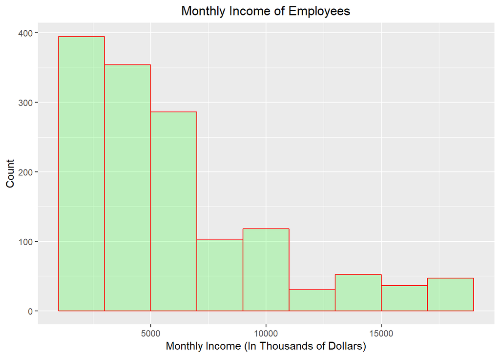

```r
##use library(ggplot2) for histogram of the Employee Monthly Income
ggplot(data=empdata.tidy, aes(MonthlyInc)) +
  geom_histogram(breaks=seq(1000, 20000, by = 2000),
                 col="red",
                 fill="green",
                 alpha=.2) +
  labs(title="Monthly Income of Employees", x="Monthly Income (In Thousands of Dollars)", y="Count")+
  theme(plot.title = element_text(hjust = 0.5))
```

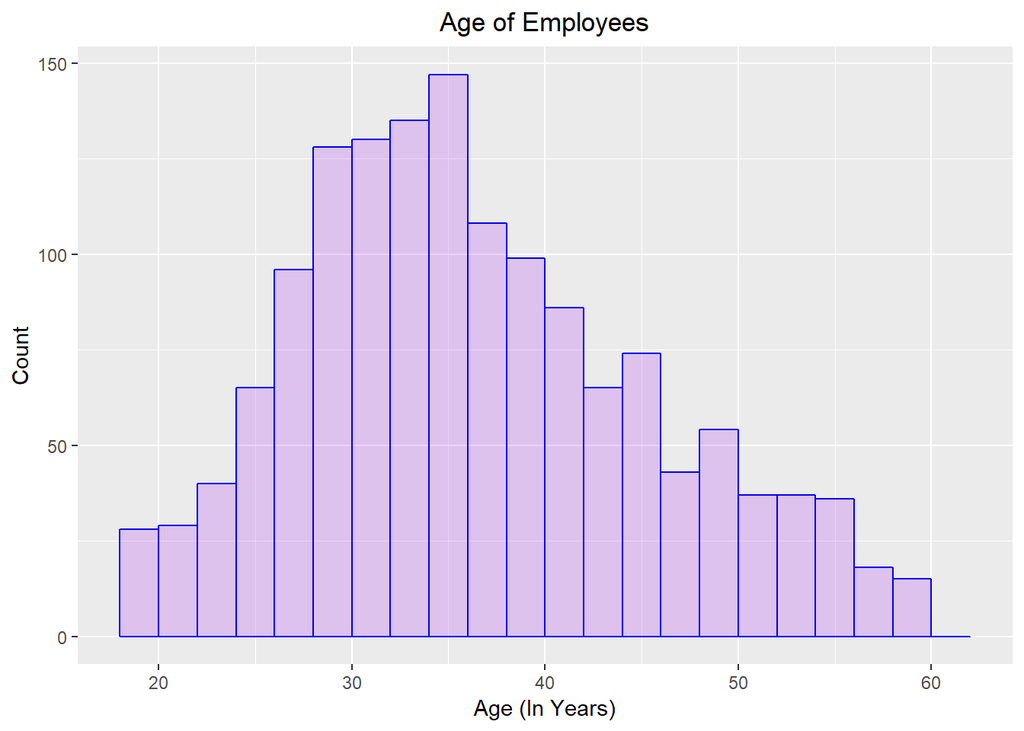

```r
##Historgram of the Employee Ages visually describe the company population
ggplot(data=empdata.tidy, aes(Age)) +
  geom_histogram(breaks=seq(18, 62, by = 2),
                 col="blue",
                 fill="purple",
                 alpha=.2) +
    labs(title="Age of Employees", x="Age (In Years)", y="Count")+
  theme(plot.title = element_text(hjust = 0.5))
```

```r
##Create Frequency tables for Gender, Education and Occupation (JobRoles) Using library(summarytools)
summarytools::freq(empdata.tidy$Gender, order = "freq")
```

```
## Frequencies
## empdata.tidy$Gender
## Type: Factor (unordered)
##
##                Freq   % Valid   % Valid Cum.   % Total   % Total Cum.
## ------------ ------ --------- -------------- --------- --------------
##         Male    882     60.00          60.00     60.00          60.00
##       Female    588     40.00         100.00     40.00         100.00
##         <NA>      0                               0.00         100.00
##        Total   1470    100.00         100.00    100.00         100.00
```

```r
edu <- matrix(c(sum(empdata.tidy$Education == "1"),
                sum(empdata.tidy$Education == "2"),
                sum(empdata.tidy$Education == "3"),
                sum(empdata.tidy$Education == "4"),
                sum(empdata.tidy$Education == "5")),ncol=1,byrow=TRUE)
rownames(edu) <- c("Below College", "College", "Bachelor", "Master", "Doctor")
colnames(edu) <- c("Sums")
edu
```

```
##               Sums
## Below College  170
## College        282
## Bachelor       572
## Master         398
## Doctor          48
```

```r
summarytools::freq(empdata.tidy$JobRole, order = "freq")
```

```
## Frequencies
## empdata.tidy$JobRole
## Type: Factor (unordered)
##
##                                   Freq   % Valid   % Valid Cum.   % Total   % Total Cum.
## ------------------------------- ------ --------- -------------- --------- --------------
##                 Sales Executive    326     22.18          22.18     22.18          22.18
##              Research Scientist    292     19.86          42.04     19.86          42.04
##           Laboratory Technician    259     17.62          59.66     17.62          59.66
##          Manufacturing Director    145      9.86          69.52      9.86          69.52
##       Healthcare Representative    131      8.91          78.44      8.91          78.44
##                         Manager    102      6.94          85.37      6.94          85.37
##            Sales Representative     83      5.65          91.02      5.65          91.02
##               Research Director     80      5.44          96.46      5.44          96.46
##                 Human Resources     52      3.54         100.00      3.54         100.00
##                            <NA>      0                               0.00         100.00
##                           Total   1470    100.00         100.00    100.00         100.00
```

```r
##Management count and table
manage <- empdata.tidy %>%
  filter(empdata.tidy$JobLevel=="5")
management <- table(as.character(manage$JobRole))
addmargins(management)
```

```
##
##           Manager Research Director               Sum
##                43                26                69
```

### Find a suitable model for Attrition based on given data

To determine the initial model, glm is used. It allows us to give option of defining response variable as binomial, for the given dataset, Attrition is the response variable and has 2 values , TRUE/FALSE. For glm, R converts categorical variables into indicator variables. It does not like spaces in categorical values, so the given dataset is modified first to remove spaces from the categorical variables.

**initial model**

```r
#stepwise regression
empdata.tidy.multfact <- empdata.tidy[, !(colnames(empdata.tidy) %in% c("EmployeeCnt","StandardHrs", "Over18","stringAsFactors","EducDesc","EnvirSatDesc","JobInvlvDesc","JobSatDesc","RlshpSatDesc","PerfRtgDesc","WkLifBalDesc"))]
empdata.tidy.multfact.orig <- empdata.tidy.multfact
empdata.tidy.multfact$Attrition <-  as.numeric(empdata.tidy.multfact$Attrition)-1

#remove white spaces from values in factors
empdata.tidy.multfact.spaceless <- empdata.tidy.multfact
empdata.tidy.multfact.spaceless[,c("BusinessTrvl","Department","EducationFld","JobRole")] <- as.data.frame(apply(empdata.tidy.multfact.spaceless[,c("BusinessTrvl","Department","EducationFld","JobRole")],2,function(x)gsub('\\s+', '',x)))


## caret pkg has varImp function
#library(caret)

#use glm , it allows us to give option of defining response variable as binomial
# Initial model
glmMod <- glm(as.numeric(Attrition) ~ . , data = empdata.tidy.multfact.spaceless, binomial)

# summary of initial model

summary(glmMod)
```

```
##
## Call:
## glm(formula = as.numeric(Attrition) ~ ., family = binomial, data = empdata.tidy.multfact.spaceless)
##
## Deviance Residuals:
##     Min       1Q   Median       3Q      Max
## -1.8141  -0.4439  -0.1942  -0.0546   3.6613
##
## Coefficients:
##                                  Estimate Std. Error z value Pr(>|z|)
## (Intercept)                    -1.031e+01  5.827e+02  -0.018 0.985886
## Age                            -3.123e-02  1.444e-02  -2.163 0.030508 *
## BusinessTrvlTravel_Frequently   2.145e+00  4.465e-01   4.803 1.57e-06 ***
## BusinessTrvlTravel_Rarely       1.134e+00  4.122e-01   2.752 0.005919 **
## DailyRate                      -4.485e-04  2.353e-04  -1.906 0.056667 .
## DepartmentResearch&Development  1.441e+01  5.827e+02   0.025 0.980273
## DepartmentSales                 1.356e+01  5.827e+02   0.023 0.981436
## DistFromHome                    5.565e-02  1.162e-02   4.792 1.66e-06 ***
## Education2                      2.535e-01  3.490e-01   0.726 0.467573
## Education3                      2.495e-01  3.060e-01   0.815 0.414819
## Education4                      2.802e-01  3.347e-01   0.837 0.402475
## Education5                      2.057e-01  6.340e-01   0.325 0.745549
## EducationFldLifeSciences       -1.168e+00  8.913e-01  -1.311 0.189952
## EducationFldMarketing          -6.305e-01  9.359e-01  -0.674 0.500554
## EducationFldMedical            -1.162e+00  8.897e-01  -1.306 0.191467
## EducationFldOther              -1.023e+00  9.619e-01  -1.064 0.287504
## EducationFldTechnicalDegree     8.993e-03  9.035e-01   0.010 0.992059
## EmployeeNum                    -2.079e-04  1.628e-04  -1.277 0.201725
## EnvirSatisf2                   -1.109e+00  2.960e-01  -3.746 0.000180 ***
## EnvirSatisf3                   -1.239e+00  2.719e-01  -4.558 5.17e-06 ***
## EnvirSatisf4                   -1.436e+00  2.741e-01  -5.241 1.60e-07 ***
## GenderMale                      4.459e-01  1.967e-01   2.267 0.023365 *
## HourlyRate                      4.605e-03  4.772e-03   0.965 0.334495
## JobInvolvmnt2                  -1.284e+00  3.795e-01  -3.383 0.000718 ***
## JobInvolvmnt3                  -1.576e+00  3.578e-01  -4.404 1.06e-05 ***
## JobInvolvmnt4                  -2.204e+00  4.928e-01  -4.472 7.74e-06 ***
## JobLevel2                      -1.587e+00  4.828e-01  -3.288 0.001009 **
## JobLevel3                       1.325e-01  7.404e-01   0.179 0.857946
## JobLevel4                      -7.757e-01  1.277e+00  -0.607 0.543589
## JobLevel5                       2.293e+00  1.672e+00   1.372 0.170168
```

[output cut: 29 more lines]

```
## WorkLifeBal4                   -1.076e+00  4.473e-01  -2.405 0.016186 *
## YrsAtFirm                       1.025e-01  4.289e-02   2.390 0.016867 *
## YrsInCurRole                   -1.457e-01  5.202e-02  -2.801 0.005101 **
## YrsSncePromo                    1.751e-01  4.611e-02   3.797 0.000147 ***
## YrsWthCurMgr                   -1.569e-01  5.074e-02  -3.093 0.001982 **
## ---
## Signif. codes:  0 '***' 0.001 '**' 0.01 '*' 0.05 '.' 0.1 ' ' 1
##
## (Dispersion parameter for binomial family taken to be 1)
##
##     Null deviance: 1298.58  on 1469  degrees of freedom
## Residual deviance:  773.66  on 1406  degrees of freedom
## AIC: 901.66
##
## Number of Fisher Scoring iterations: 15
```

```r
# Intial model statistics

glmMod$aic
```

```
## [1] 901.6605
```

AIC statistics for this model is 901.66.

**reduced model**

```r
# perform stepwise on the glm
reducedMod <- step(glmMod)
```

```
## Start:  AIC=901.66
## as.numeric(Attrition) ~ Age + BusinessTrvl + DailyRate + Department +
##     DistFromHome + Education + EducationFld + EmployeeNum + EnvirSatisf +
##     Gender + HourlyRate + JobInvolvmnt + JobLevel + JobRole +
##     JobSatisf + MaritalStat + MonthlyInc + MonthlyRate + NumFirmsWrkd +
##     OverTime + PctSalryHike + PerforRating + RelshipSatis + StockOptLvl +
##     TotlWrkngYrs + TrnCntLastYr + WorkLifeBal + YrsAtFirm + YrsInCurRole +
##     YrsSncePromo + YrsWthCurMgr
##
##                Df Deviance     AIC
## - Education     4   774.50  894.50
## - PerforRating  1   773.71  899.71
## - Department    2   775.91  899.91
## - PctSalryHike  1   773.98  899.98
## - MaritalStat   2   776.18  900.18
## - MonthlyRate   1   774.39  900.39
## - HourlyRate    1   774.59  900.59
## - EmployeeNum   1   775.30  901.30
## - MonthlyInc    1   775.41  901.41
## <none>              773.66  901.66
## - DailyRate     1   777.32  903.32
## - TotlWrkngYrs  1   777.48  903.48
## - Age           1   778.48  904.48
## - Gender        1   778.91  904.91
## - YrsAtFirm     1   779.37  905.37
## - TrnCntLastYr  1   779.96  905.96
## - YrsInCurRole  1   781.54  907.54
## - EducationFld  5   789.60  907.60
## - YrsWthCurMgr  1   783.15  909.15
## - StockOptLvl   3   787.85  909.85
## - JobRole       8   798.86  910.86
## - WorkLifeBal   3   792.01  914.01
## - RelshipSatis  3   792.28  914.28
## - YrsSncePromo  1   788.51  914.51
## - JobSatisf     3   797.10  919.10
## - JobInvolvmnt  3   798.86  920.86
## - DistFromHome  1   796.68  922.68
## - NumFirmsWrkd  1   799.16  925.16
## - EnvirSatisf   3   805.57  927.57
## - BusinessTrvl  2   806.65  930.65
```

[output cut: 319 more lines]

```
## - YrsWthCurMgr  1   792.07  890.07
## - YrsInCurRole  1   792.18  890.18
## - YrsSncePromo  1   797.59  895.59
## - WorkLifeBal   3   802.11  896.11
## - RelshipSatis  3   802.37  896.37
## - JobSatisf     3   807.77  901.77
## - JobInvolvmnt  3   808.28  902.28
## - DistFromHome  1   806.87  904.87
## - NumFirmsWrkd  1   809.69  907.69
## - EnvirSatisf   3   814.47  908.47
## - JobLevel      4   819.30  911.30
## - JobRole       8   828.37  912.37
## - BusinessTrvl  2   817.36  913.36
## - StockOptLvl   3   842.48  936.48
## - OverTime      1   907.68 1005.68
```

```r
#summary of the selectedmodel
summary(reducedMod)
```

```
##
## Call:
## glm(formula = as.numeric(Attrition) ~ Age + BusinessTrvl + DailyRate +
##     DistFromHome + EducationFld + EnvirSatisf + Gender + JobInvolvmnt +
##     JobLevel + JobRole + JobSatisf + NumFirmsWrkd + OverTime +
##     RelshipSatis + StockOptLvl + TotlWrkngYrs + TrnCntLastYr +
##     WorkLifeBal + YrsAtFirm + YrsInCurRole + YrsSncePromo + YrsWthCurMgr,
##     family = binomial, data = empdata.tidy.multfact.spaceless)
##
## Deviance Residuals:
##     Min       1Q   Median       3Q      Max
## -1.7553  -0.4417  -0.2032  -0.0633   3.4683
##
## Coefficients:
##                                 Estimate Std. Error z value Pr(>|z|)
## (Intercept)                    3.7851181  1.2633482   2.996 0.002735 **
## Age                           -0.0282390  0.0140546  -2.009 0.044512 *
## BusinessTrvlTravel_Frequently  2.0982316  0.4332062   4.843 1.28e-06 ***
## BusinessTrvlTravel_Rarely      1.0724588  0.3972841   2.699 0.006945 **
## DailyRate                     -0.0004513  0.0002317  -1.948 0.051462 .
## DistFromHome                   0.0547174  0.0114721   4.770 1.85e-06 ***
## EducationFldLifeSciences      -0.7387781  0.8042631  -0.919 0.358317
## EducationFldMarketing         -0.2473836  0.8510396  -0.291 0.771293
## EducationFldMedical           -0.7791928  0.8060059  -0.967 0.333677
## EducationFldOther             -0.7094092  0.8831506  -0.803 0.421818
## EducationFldTechnicalDegree    0.3594166  0.8274104   0.434 0.664007
## EnvirSatisf2                  -1.0754392  0.2900961  -3.707 0.000210 ***
## EnvirSatisf3                  -1.1763190  0.2664673  -4.414 1.01e-05 ***
## EnvirSatisf4                  -1.3788833  0.2685296  -5.135 2.82e-07 ***
## GenderMale                     0.4045242  0.1943798   2.081 0.037425 *
## JobInvolvmnt2                 -1.2037665  0.3697265  -3.256 0.001131 **
## JobInvolvmnt3                 -1.5006480  0.3481340  -4.311 1.63e-05 ***
## JobInvolvmnt4                 -2.1187967  0.4819941  -4.396 1.10e-05 ***
## JobLevel2                     -1.6610472  0.4468005  -3.718 0.000201 ***
## JobLevel3                     -0.3861767  0.5643118  -0.684 0.493765
## JobLevel4                     -1.6316813  0.9884549  -1.651 0.098792 .
## JobLevel5                      0.7842021  1.2810048   0.612 0.540420
## JobRoleHumanResources          0.5134386  0.7540785   0.681 0.495946
## JobRoleLaboratoryTechnician    0.7891182  0.5922402   1.332 0.182719
## JobRoleManager                -0.9934816  1.0243904  -0.970 0.332133
```

[output cut: 20 more lines]

```
## WorkLifeBal4                  -1.0654284  0.4398874  -2.422 0.015433 *
## YrsAtFirm                      0.0980868  0.0427271   2.296 0.021695 *
## YrsInCurRole                  -0.1456140  0.0510833  -2.851 0.004365 **
## YrsSncePromo                   0.1653842  0.0453821   3.644 0.000268 ***
## YrsWthCurMgr                  -0.1433559  0.0504213  -2.843 0.004467 **
## ---
## Signif. codes:  0 '***' 0.001 '**' 0.01 '*' 0.05 '.' 0.1 ' ' 1
##
## (Dispersion parameter for binomial family taken to be 1)
##
##     Null deviance: 1298.58  on 1469  degrees of freedom
## Residual deviance:  784.02  on 1420  degrees of freedom
## AIC: 884.02
##
## Number of Fisher Scoring iterations: 7
```

```r
# reduced model statistics
reducedMod$aic
```

```
## [1] 884.0241
```

We used stepwise selection method to select the appropriate predictors for Attrition model.default dirction= “both”. AIC statistics for this model is 901.66. Stepwise selection , chose the 10th model @ AIC = 884.0241 This is not the best model but considering our prelimenary analysis, this model should be able to provide us with important predictors.

*About the stepwise selection method* step uses add1 and drop1 repeatedly; it will work for any method for which they work, and that is determined by having a valid method for extractAIC. When the additive constant can be chosen so that AIC is equal to Mallows’ Cp, this is done and the tables are labelled appropriately.

stepwise selection method:

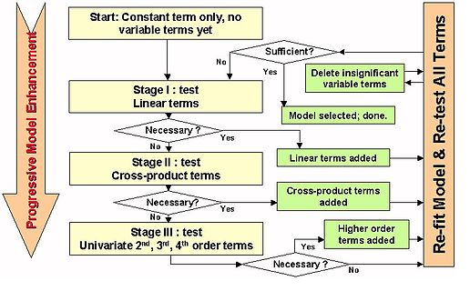

*Image courtesy: Kelas Karyawan - kurikulum.org*

**Important variables**

varImp() - A generic method for calculating variable importance for objects produced by train and method specific methods

```r
all_vars <- names(reducedMod[[1]])[-1]  # names of all X variables
# Get the non-significant vars
summ <- summary(reducedMod)  # model summary
pvals <- summ[[12]][, 4]  # get all p values
not_significant <- character()  # init variables that aren't statsitically significant
not_significant <- names(which(pvals > 0.1))
not_significant <- not_significant[!not_significant %in% "(Intercept)"]  # remove 'intercept'. Optional!

##not significant predictors
not_significant
```

```
##  [1] "EducationFldLifeSciences"     "EducationFldMarketing"
##  [3] "EducationFldMedical"          "EducationFldOther"
##  [5] "EducationFldTechnicalDegree"  "JobLevel3"
##  [7] "JobLevel5"                    "JobRoleHumanResources"
##  [9] "JobRoleLaboratoryTechnician"  "JobRoleManager"
## [11] "JobRoleManufacturingDirector" "JobRoleResearchScientist"
```

```r
#determine importance of predictors
empdata.varimp <- varImp(reducedMod)

#sort in decreasing order of variable importance

empdata.varimp.sort <- cbind(data.frame(empdata.varimp[rev(order(empdata.varimp$Overall)),]),data.frame(rownames(empdata.varimp)[order(empdata.varimp$Overall, decreasing = TRUE)[]]))
names(empdata.varimp.sort) <- c("varImp","varName")
head(empdata.varimp.sort,10)
```

```
##       varImp                       varName
## 1  10.359984                   OverTimeYes
## 2   6.798849                  StockOptLvl1
## 3   5.134939                  EnvirSatisf4
## 4   5.080591                  NumFirmsWrkd
## 5   4.843494 BusinessTrvlTravel_Frequently
## 6   4.778369                    JobSatisf4
## 7   4.769594                  DistFromHome
## 8   4.414496                  EnvirSatisf3
## 9   4.395898                 JobInvolvmnt4
## 10  4.310547                 JobInvolvmnt3
```

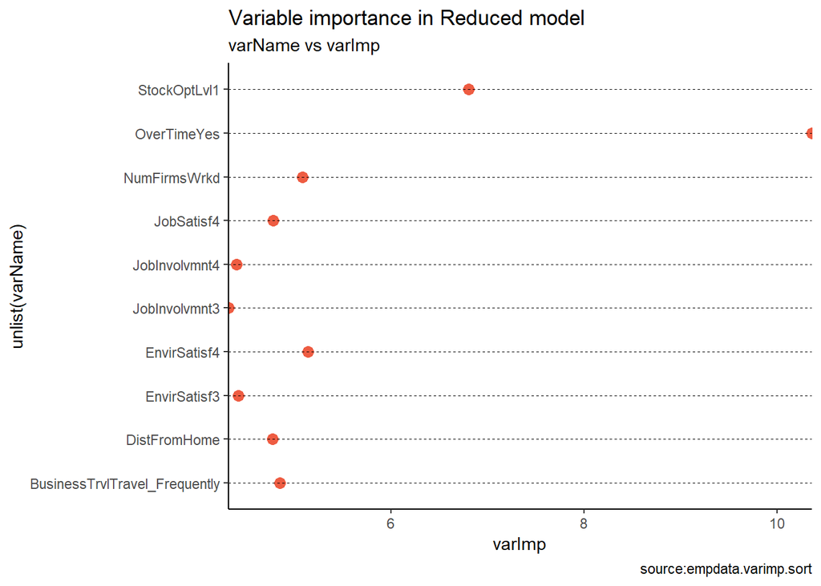

```r
theme_set(theme_classic())

#library(wordcloud)
#pal = brewer.pal(8,"Dark2")
#wordcloud(empdata.varimp.sort$varName , freq = empdata.varimp.sort$varImp*100, max.words = 100, random.order = FALSE, random.colours = FALSE, colors = pal, scale = c(5,0.3), rot.per = 0.15)
ggplot(empdata.varimp.sort[1:10,], aes(x=unlist(varName), y=varImp)) + geom_point( col="tomato2", size=3) + scale_y_continuous(expand = c(0,0)) + geom_segment(aes(x=unlist(varName), xend = unlist(varName), y=min(varImp), yend=max(varImp)), linetype="dashed", size=0.1) + labs(title="Variable importance in Reduced model", subtitle="varName vs varImp", caption="source:empdata.varimp.sort") + coord_flip()
```

Above plot has top 10 important factors from our selected Model. We will discuss the top 3 -

1- OVerTime  
2- StockOptions  
3- Environment Satisfaction  
### Visualize attrition and some of its factors

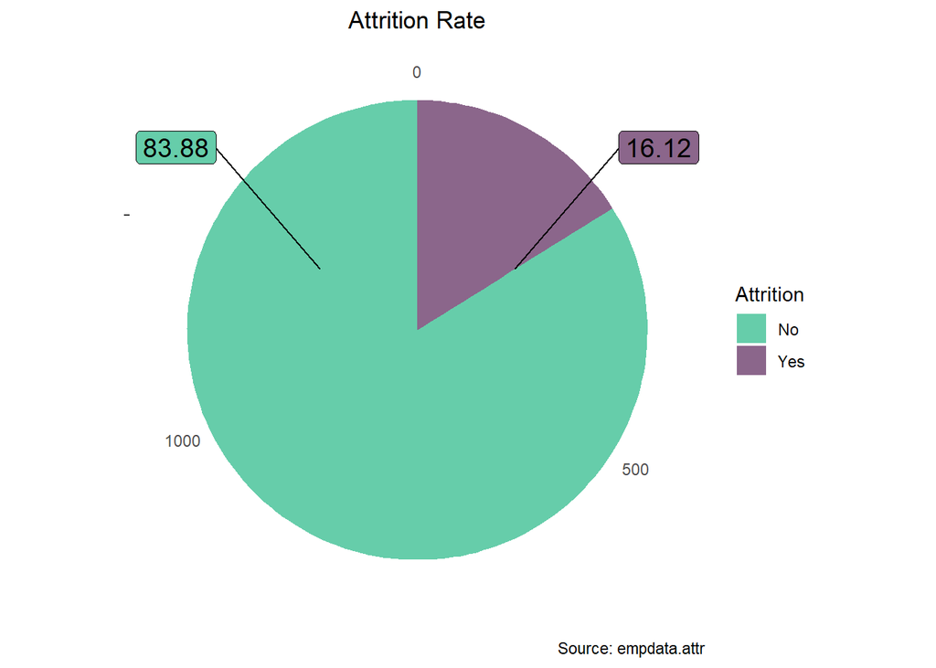

```r
#create frequency and percentage table
empdata.attr <- as.data.frame(empdata.tidy.multfact.orig %>% group_by(Attrition) %>%tally() %>%  mutate(percent = round(n*100/sum(n),2)) )
colnames( empdata.attr) <- c("Attrition","freq","percent")

#select colors
fill_attr <- c("mediumaquamarine", "plum4")

#plot attrition rate
ggplot(empdata.attr, aes(x="", y=freq, fill=Attrition)) + geom_bar(width = 1, stat= "identity") + theme(axis.line = element_blank(), plot.title = element_text(hjust=0.5), panel.background = element_blank()) +  labs(fill="Attrition", x=NULL, y=NULL, title="Attrition Rate", caption="Source: empdata.attr") + coord_polar(theta = "y", start=0) + geom_label_repel(aes(label=percent), size=5, show.legend=FALSE, nudge_x=1) +scale_fill_manual(values=fill_attr)
```

In the past year we have seen 16% Attrition in this company. Let’s analyze some of these factors and see if there is any relation with Attrition.

**OverTime and Attrition**

Overtime can be positive in that it allows employees the opportunity to make extra money and to make their mark on their workplaces, but it can also be negative in that too much overtime can lead to employee burnout.When employees are overworked, they become less productive and are more inclined to quit their job for other opportunities.

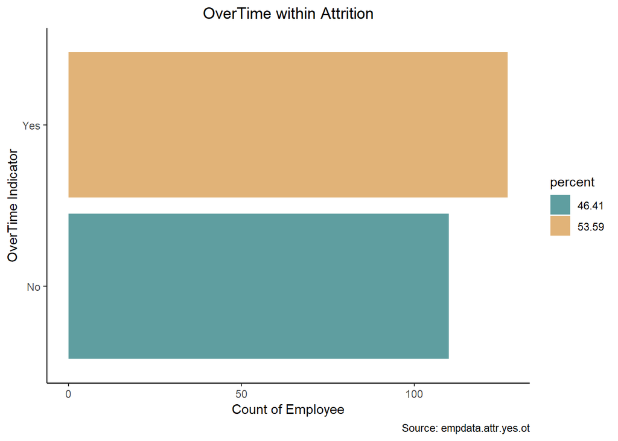

```r
# Analyze talent lost

# How many did overtime ?
# get counts and percent of people with Overtime where Attrition = Yes
empdata.attr.yes.ot <- as.data.frame(empdata.tidy.multfact.orig %>% filter(Attrition == "Yes") %>% group_by(OverTime) %>%tally() %>% arrange(desc(n)) %>% mutate(percent = round(n*100/sum(n),2)))
colnames( empdata.attr.yes.ot) <- c("OverTime","freq","percent")

empdata.attr.no.ot <- as.data.frame(empdata.tidy.multfact.orig %>% filter(Attrition == "No") %>% group_by(OverTime) %>%tally() %>% arrange(desc(n)) %>% mutate(percent = round(n*100/sum(n),2)))
colnames( empdata.attr.no.ot) <- c("OverTime","freq","percent")

#for plotting convert percent to factor
empdata.attr.yes.ot$percent = as.factor(empdata.attr.yes.ot$percent)
empdata.attr.no.ot$percent = as.factor(empdata.attr.no.ot$percent)
#theme_set(theme_bw())  # pre-set the bw theme.

# create stacked bar chart
ggplot(data= empdata.attr.yes.ot) + geom_bar(aes(x=OverTime,y = freq, fill = percent), stat = "identity",position="stack") + scale_fill_manual(values=c("#5F9EA0", "#E1B378")) + coord_flip() + labs( title="OverTime within Attrition", caption="Source: empdata.attr.yes.ot") +xlab("OverTime Indicator") + ylab("Count of Employee") + theme( plot.title = element_text(hjust=0.5), panel.background = element_blank())
```

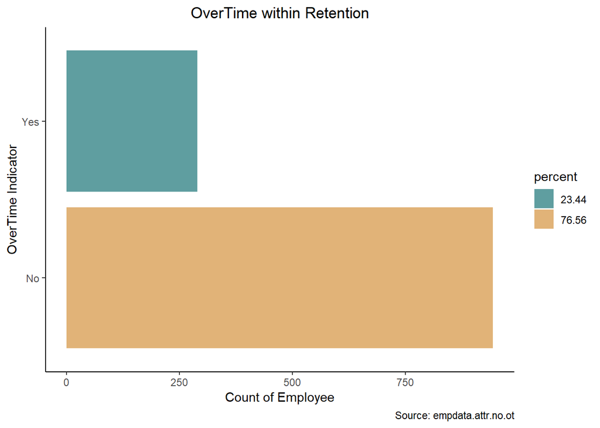

```r
#ggplot(data= empdata.attr.no.ot) + geom_bar(aes(x=OverTime,y = freq, fill = percent), stat = "identity",position="stack") + scale_fill_manual(values=c("#CC6666", "#9999CC", "#66CC99")) + coord_flip() + labs( title="OverTime within Retention", caption="Source: empdata.attr.no.ot") +xlab("OverTime Indicator") + ylab("Count of Employee")  + theme( plot.title = element_text(hjust=0.5), panel.background = element_blank())
ggplot(data= empdata.attr.no.ot) + geom_bar(aes(x=OverTime,y = freq, fill = percent), stat = "identity",position="stack") + scale_fill_manual(values=c("#5F9EA0", "#E1B378")) + coord_flip() + labs( title="OverTime within Retention", caption="Source: empdata.attr.no.ot") +xlab("OverTime Indicator") + ylab("Count of Employee")  + theme( plot.title = element_text(hjust=0.5), panel.background = element_blank())
```

There are 200+ people leaving the company , out of which about 54% did Overtime. The plot showing retention, about 24% employees did overtime. POints to consider -

- What is the need for OverTime? Is this requirement concentrated to cetain departments ?
- Are you compensating your employees enough for the overtime ?

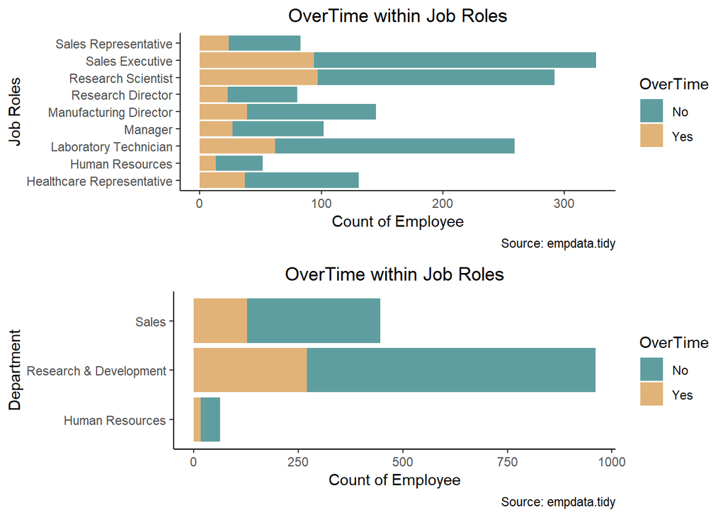

```r
#plot OverTime within JobRole
plot1 <- ggplot(data= empdata.tidy, aes(x=empdata.tidy$JobRole,fill = OverTime)) + geom_bar() + scale_fill_manual(values=c("#5F9EA0", "#E1B378")) + coord_flip() + labs( title="OverTime within Job Roles", caption="Source: empdata.tidy") +xlab("Job Roles") + ylab("Count of Employee") + theme( plot.title = element_text(hjust=0.5), panel.background = element_blank())

#plot OverTime within Departments
plot2 <- ggplot(data= empdata.tidy, aes(x=empdata.tidy$Department,fill = OverTime)) + geom_bar() + scale_fill_manual(values=c("#5F9EA0", "#E1B378")) + coord_flip() + labs( title="OverTime within Job Roles", caption="Source: empdata.tidy") +xlab("Department") + ylab("Count of Employee") + theme( plot.title = element_text(hjust=0.5), panel.background = element_blank())

grid.arrange(plot1,plot2, nrow=2,ncol=1)
```

Reviewing different areas within the company, top 2 contenders for OVerTime are Research Scientist and Sales Executive roles. Most of the OVerTime is seen within the Research & Development Department.

**Stock Options and Attrition** Traditionally, stock option plans have been used as a way for companies to reward top management and “key” employees and link their interests with those of the company and other shareholders.Stock Option plans may be intended to give all employees stock in the company or to just provide a benefit for some “key” employees

```r
#create frequency and percent for stockoptions and Attrition

detach("package:plyr", unload=TRUE)
empdata.attr.inv <- as.data.frame(empdata.tidy.multfact.orig %>% group_by(Attrition,StockOptLvl) %>% summarise( n=n()) %>% arrange(desc(n)) %>% mutate(percent = round(n*100/sum(n),2)))

empdata.attr.inv
```

```
##   Attrition StockOptLvl   n percent
## 1        No           1 540   43.80
## 2        No           0 477   38.69
## 3       Yes           0 154   64.98
## 4        No           2 146   11.84
## 5        No           3  70    5.68
## 6       Yes           1  56   23.63
## 7       Yes           3  15    6.33
## 8       Yes           2  12    5.06
```

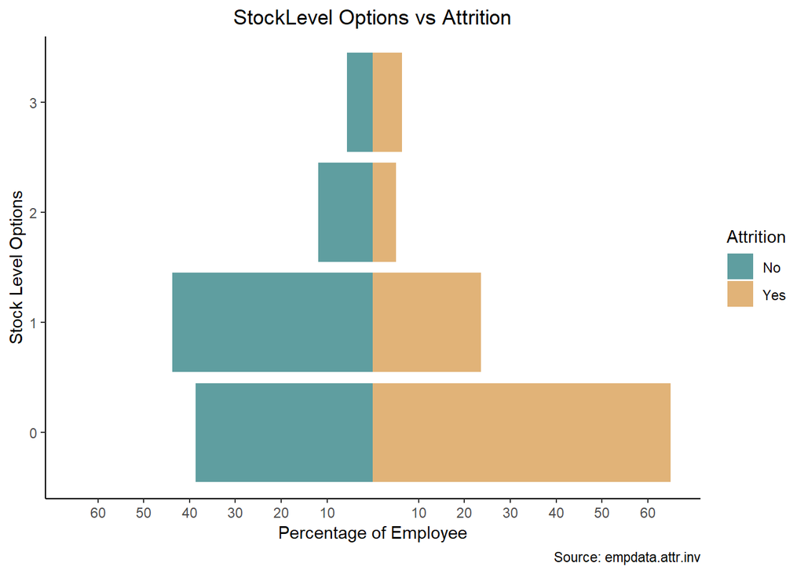

```r
# Plot
fill <- c("#5F9EA0", "#E1B378")
ggplot(data = empdata.attr.inv, mapping = aes(x = StockOptLvl, fill = Attrition, y = ifelse(test = Attrition == "Yes" , yes = percent, no = -percent))) + geom_bar(stat="identity") + scale_y_continuous(labels = abs, limits = max(empdata.attr.inv$percent)* c(-1, 1), breaks = c(-10,-20,-30,-40,-50,-60,10,20,30,40,50,60)) +  scale_fill_manual(values=fill) +coord_flip() + labs( title="StockLevel Options vs Attrition", caption="Source: empdata.attr.inv") +xlab("Stock Level Options") + ylab("Percentage of Employee")  + theme( plot.title = element_text(hjust=0.5), panel.background = element_blank())
```

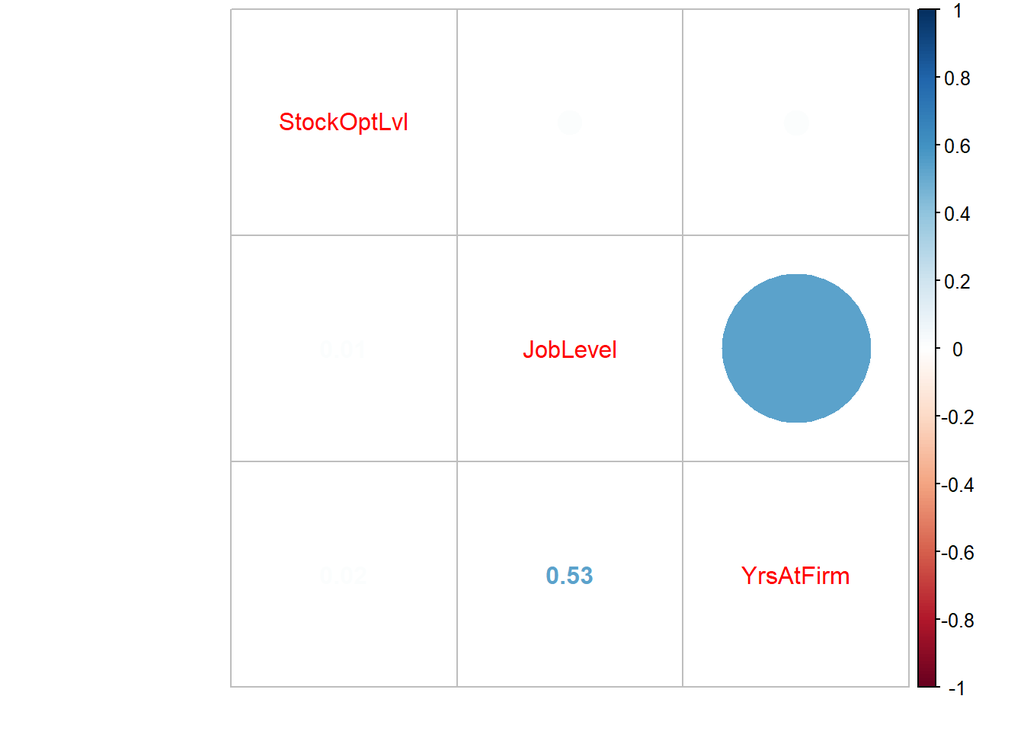

```r
#Correlation between Stock Options and Job Level and Years at Firm
empdata.cor1.ds <- data.frame(as.numeric(empdata.tidy.multfact$StockOptLvl),as.numeric(empdata.tidy.multfact$JobLevel),as.numeric(empdata.tidy.multfact$YrsAtFirm))
names(empdata.cor1.ds) <- c("StockOptLvl","JobLevel","YrsAtFirm")

empdata.cor1 <- cor(empdata.cor1.ds)
corrplot.mixed(empdata.cor1)
```

One would tend to think Stock Options would be correlated to Job Levels or Years at Firm, but based on our data, there is no correlation between them. There is some correlation between Job Levels and Years at Firm but none with StockOptions.

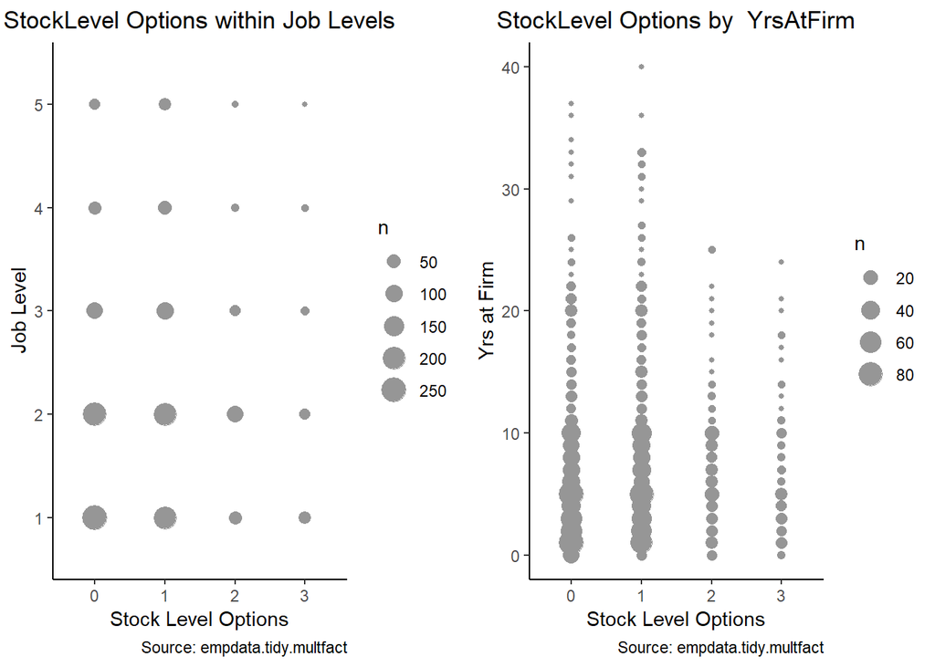

```r
#plot stockoptions at job level
plot3 <- ggplot(empdata.tidy.multfact, aes(x=StockOptLvl,y=JobLevel)) + geom_count(col="grey59", show.legend=T) + labs( title="StockLevel Options within Job Levels", caption="Source: empdata.tidy.multfact") +xlab("Stock Level Options") + ylab("Job Level")  + theme( plot.title = element_text(hjust=0.5))

#plot stockoptions by Yrs at Firm
plot4 <- ggplot(empdata.tidy.multfact, aes(x=StockOptLvl,y=YrsAtFirm)) + geom_count(col="grey59", show.legend=T) + labs( title="StockLevel Options by  YrsAtFirm", caption="Source: empdata.tidy.multfact") +xlab("Stock Level Options") + ylab("Yrs at Firm")  + theme( plot.title = element_text(hjust=0.5))

grid.arrange(plot3,plot4, nrow=1,ncol=2)
```

Most of the employees have lower stockOptions i.e. 0 and 1 .Most of the employees are within the 10 years at firm and still have options 0 and 1 only. It is posssible higher stock options maybe only for key employees , but looking at the attrition pattern within employees having stock Option 0 is not enough to retain them. Maybe it is time to revise these options to make them attractive for employees.

**Environment Satisfaction and Attrition**

Many businesses fail to understand the importance of working environment for employee . Employee us an essential component in the process of achieving the mission and vision of business. To meet the standards of organization, employees need a working environment that allows them to work freely without problems that may restrain them from performing upto the level of their full potential.Work environment consists of employees safety, job security, relations with co-workers, work recognition , motivation for performing well among many others.

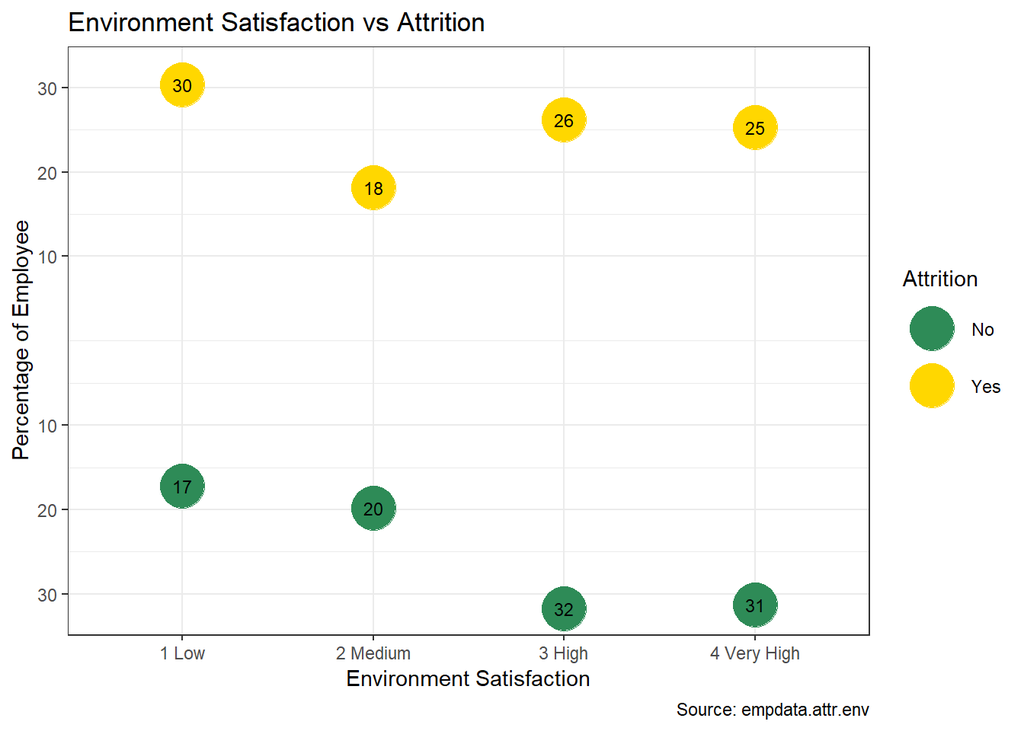

```r
#create frequency and percent for Environment Satisfaction and Attrition
empdata.attr.env <- as.data.frame(empdata.tidy %>% group_by(Attrition,EnvirSatDesc) %>% summarise( n=n()) %>% arrange(desc(n)) %>% mutate(percent = round(n*100/sum(n),2)))


cbbPalette <- c("seagreen","gold")
ggplot(data = empdata.attr.env, mapping = aes(x = EnvirSatDesc, fill = Attrition, y = ifelse(test = Attrition == "Yes" , yes = percent, no = -percent))) + geom_point(stat="identity", aes(col=Attrition), size=10) + scale_y_continuous(labels = abs, limits = max(empdata.attr.env$percent)* c(-1, 1), breaks = c(-10,-20,-30,-40,-50,-60,10,20,30,40,50,60)) + labs(y="percent", x="Environment Satisfaction") + scale_colour_manual(values=cbbPalette) + geom_text(label=round(empdata.attr.env$percent,0), size = 3, color="black") + labs( title="Environment Satisfaction vs Attrition", caption="Source: empdata.attr.env") +xlab("Environment Satisfaction") + ylab("Percentage of Employee")  + theme( plot.title = element_text(hjust=0.5), panel.background = element_blank()) + theme_bw ()
```

About 30% of the employees leaving the company show low environment satisfaction.Close to 50% people leaving the company had high environment satisfaction but there could be other factors leading them to seek other oportunities .

Skip level meetings are a suggested way to get feedback about immediate supervisors . Periodic performance appreciations and team building activities are a good way to boost a positive work environment.

### Data Visualization

In visualizing the data, specific variables are examined to determine other relationships that may exist. The first variables to be examined are Age and Income. Income was chosen to be represented by Monthly Income over the other rate options. The bar plot provides one visualization of the total monthly income for each age of employees in the company by gender.

Based on the plot, for the majority of age groups, males as a total are compensated a higher amount than females as a total. That is something for TARA to consider and potentially be concerned about when looking at attrition, as equal pay is very important for females when looking at career opportunities. The trend of the graph highlights that individuals in the middle of their career tend to make the most money, while newer and very seasoned employees see a smaller income. It is important for TARA to consider income in an appeal to the newer and seasoned population, to retain great minds and the future leaders.

The scatterplot is a second visualization of the same data. Based on the fit line, it is clear there is a positive relationship between age and monthly income, having a trend of income increasing with age. However, as age increases, it is also visible that the range of income grows. This plot supports the older employees having a larger income, however, based on the bar plot representation, that may not necessarily be the case. TARA may benefit from evaluating their financial compensation among employees to make sure it is appropriate and reflective of value added to the company.

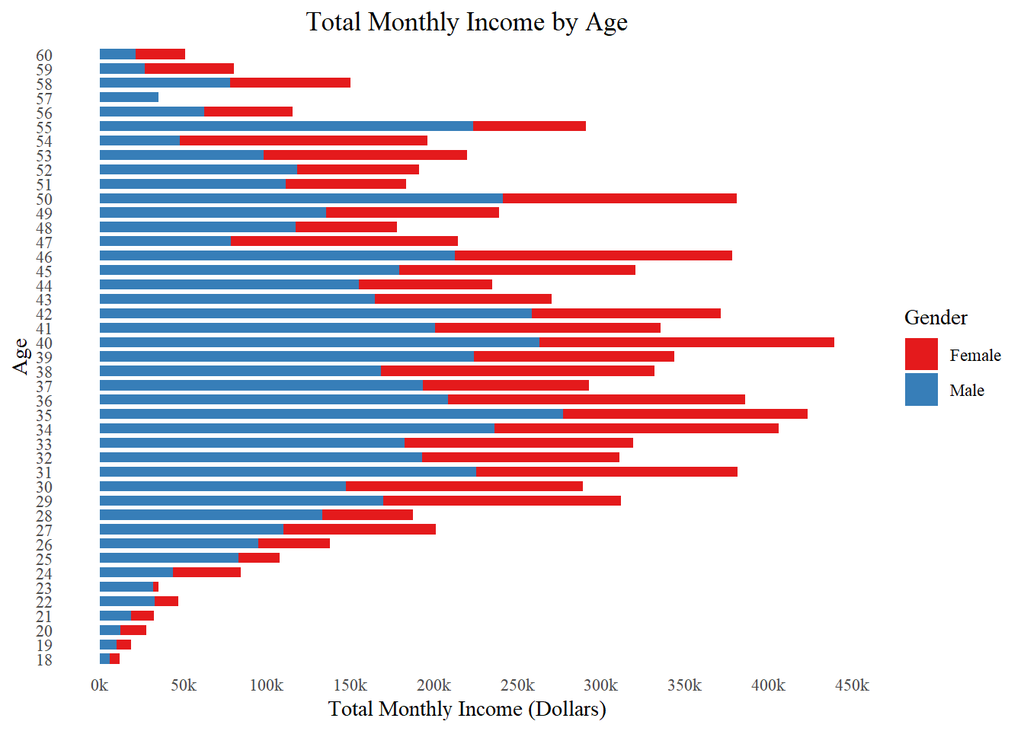

```r
#first bar plot representation of Total Monthly Income by Age
#remove exponential scaling of numbers
options(scipen = 999)
#set limits for plot and specify axis labels
brks <- seq(-500000, 500000, 50000)
lbls <- paste0(as.character(c(seq(500, 0, -50), seq(50, 500, 50))), "k")
ggplot(empdata.tidy, aes(x=reorder(Age, Age), y=MonthlyInc, fill=Gender)) +
  geom_bar(stat="identity", width=.7, position="stack") + scale_y_continuous(breaks=brks, labels=lbls) +
  coord_flip() + labs(title="Total Monthly Income by Age", x="Age", y="Total Monthly Income (Dollars)") +
  theme_tufte() + theme(plot.title = element_text(hjust=.5), axis.ticks = element_blank()) +
  scale_fill_brewer(palette = "Set1")
```

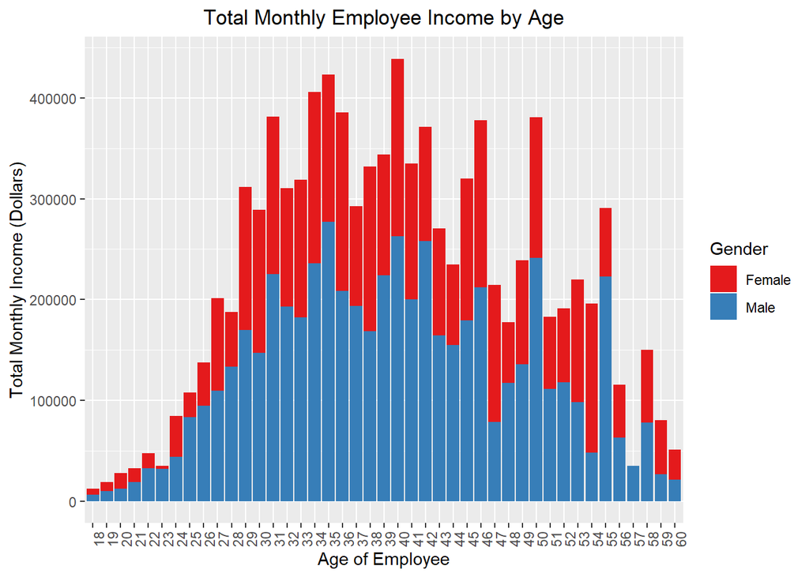

```r
#second bar plot representation of Total Monthly Income by Age
options(scipen = 999)
ggplot(empdata.tidy, aes(x=reorder(Age, Age), y=MonthlyInc, fill=Gender)) +
  geom_bar(stat="identity", position = "stack", size =.3) +
  scale_fill_brewer(palette="Set1") + theme_gray() +
  labs(title="Total Monthly Employee Income by Age", x="Age of Employee", y="Total Monthly Income (Dollars)") +
  theme(plot.title = element_text(hjust=0.5)) + theme(axis.text.x = element_text(angle = 90, hjust = 1))
```

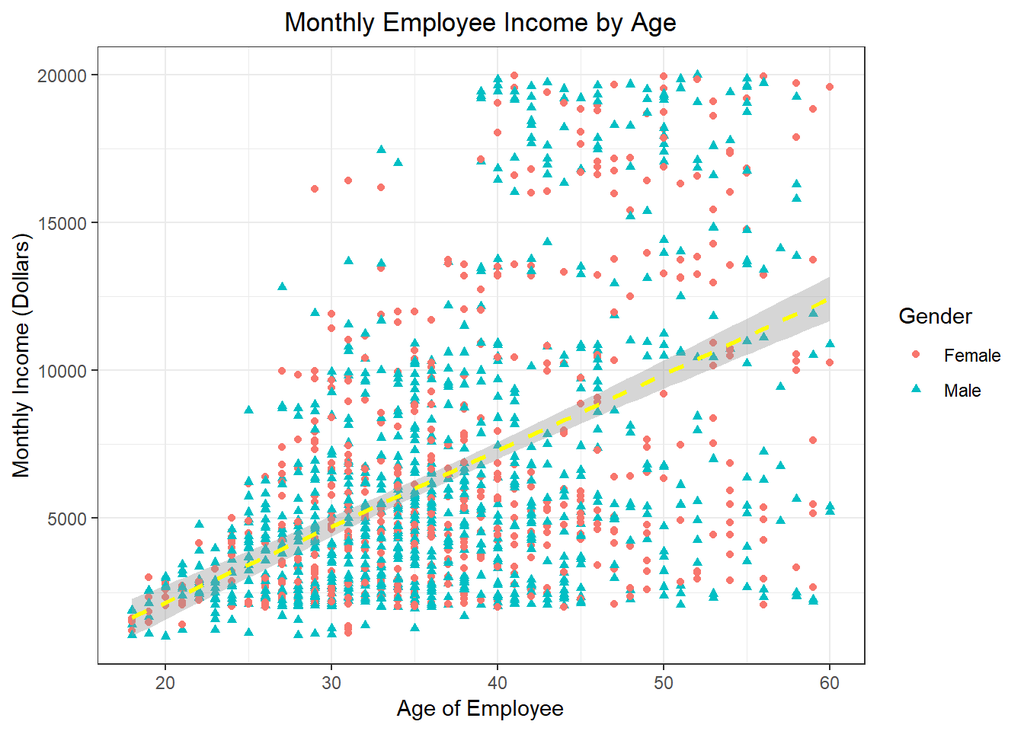

```r
#scatterplot of Total Monthly Income by Age with a linear model fit line and 99% confidence level interval
ggplot(empdata.tidy, aes(Age, MonthlyInc)) + geom_point(aes(shape=Gender, colour = Gender)) + theme_bw() +
  geom_smooth(method=lm, linetype="dashed", color="yellow", level=0.99) +
  labs(title="Monthly Employee Income by Age", x="Age of Employee", y="Monthly Income (Dollars)") +
  theme(plot.title = element_text(hjust=0.5))
```

The second visualization focuses on understanding the factors that directly influence overall work-life satisfaction. DDS Analytics determined the following variables are the most important in determining work-life satisfaction: work-life balance, environment satisfaction, job involvement, job satisfaction, performance rating, and work-relationship satisfaction. All of these play a role in an employee’s motivation, accountability, and overall attitude towards working. Employers often focus on the work at hand, forgetting the employee and the hard work required every day.

Histograms were chosen to represent the ratings and percentage of employees that put themselves in each category. Although there are many positive ratings, it is important to note the presence of negative ratings. As Environment Satisfaction was modeled with attrition earlier, TARA might choose to have the same modeling performed on Job and Relationship Satisfaction to gain a deeper understanding of attrition.

Averages were calculated for each factor based on rating, and the averages across the categories hover around a 2.7. That number represents more than just “Medium/Good”, but less than “High/Excellent/Better”. Although the averages are on the positive side, TARA needs to look at what programs and resources can be implemented to shift the average towards “Very High/Outstanding/Best”. This could involve things such as greater recognition for work, open communication with management, and more transparency in communication and planning. The company needs to raise overall work-life satisfaction, as seen above, environment satisfaction was deemed one of the top three factors for attrition.

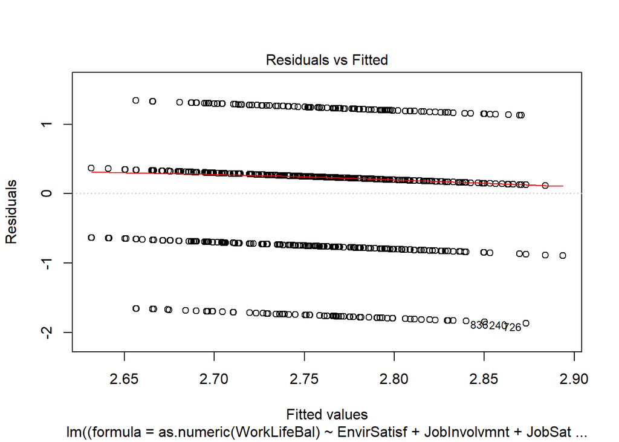

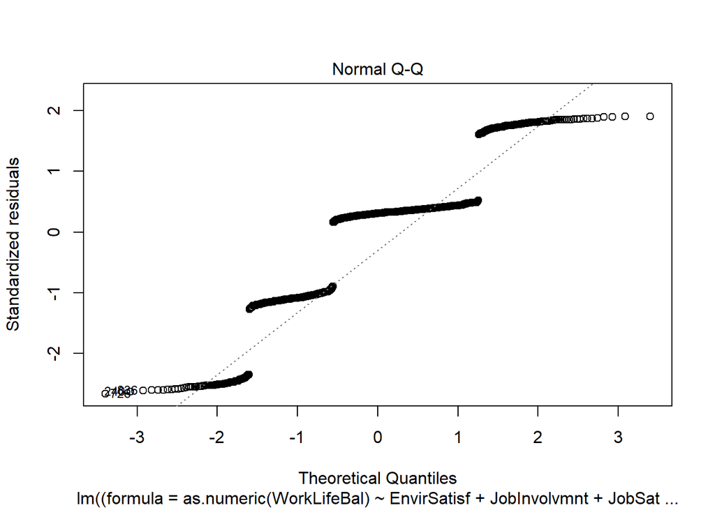

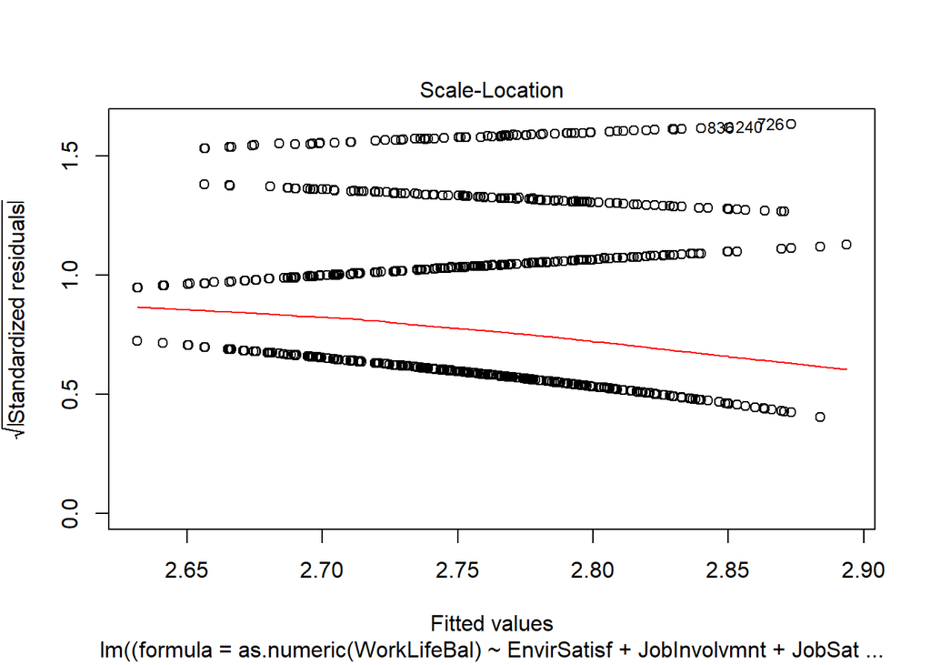

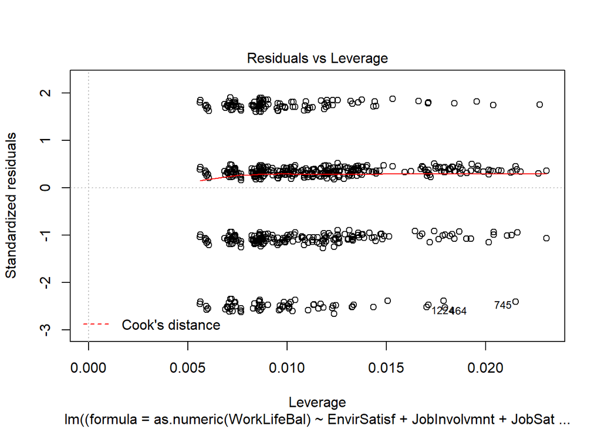

```r
#examine linear regression model of the data with variables attributed to work life satisfaction
trial <- lm((formula = as.numeric(WorkLifeBal) ~ EnvirSatisf + JobInvolvmnt + JobSatisf + PerforRating + RelshipSatis), data = empdata.tidy)
plot(trial)
```

```r
#get percentages for each rating of Work Life Balance
empdata.WorkLifeBal <- as.data.frame(empdata.tidy %>% group_by(WorkLifeBal) %>% summarise( n=n()) %>% mutate(percent = round(n*100/sum(n),2)))
empdata.WorkLifeBal
```

```
##   WorkLifeBal   n percent
## 1           1  80    5.44
## 2           2 344   23.40
## 3           3 893   60.75
## 4           4 153   10.41
```

```r
#get percentages for each rating of Environment Satisfaction
empdata.EnvirSatisf <- as.data.frame(empdata.tidy %>% group_by(EnvirSatisf) %>% summarise( n=n()) %>% mutate(percent = round(n*100/sum(n),2)))
empdata.EnvirSatisf
```

```
##   EnvirSatisf   n percent
## 1           1 284   19.32
## 2           2 287   19.52
## 3           3 453   30.82
## 4           4 446   30.34
```

```r
#get percentages for each rating of Job Involvement
empdata.JobInvolvmnt <- as.data.frame(empdata.tidy %>% group_by(JobInvolvmnt) %>% summarise( n=n()) %>% mutate(percent = round(n*100/sum(n),2)))
empdata.JobInvolvmnt
```

```
##   JobInvolvmnt   n percent
## 1            1  83    5.65
## 2            2 375   25.51
## 3            3 868   59.05
## 4            4 144    9.80
```

```r
#get percentages for each rating of Job Satisfaction
empdata.JobSatisf <- as.data.frame(empdata.tidy %>% group_by(JobSatisf) %>% summarise( n=n()) %>% mutate(percent = round(n*100/sum(n),2)))
empdata.JobSatisf
```

```
##   JobSatisf   n percent
## 1         1 289   19.66
## 2         2 280   19.05
## 3         3 442   30.07
## 4         4 459   31.22
```

```r
#get percentages for each rating of Performance Rating
empdata.PerforRating <- as.data.frame(empdata.tidy %>% group_by(PerforRating) %>% summarise( n=n()) %>% mutate(percent = round(n*100/sum(n),2)))
empdata.PerforRating
```

```
##   PerforRating    n percent
## 1            3 1244   84.63
## 2            4  226   15.37
```

```r
#get percentages for each rating of Work Relationship Satisfaction
empdata.RelshipSatis <- as.data.frame(empdata.tidy %>% group_by(RelshipSatis) %>% summarise( n=n()) %>% mutate(percent = round(n*100/sum(n),2)))
empdata.RelshipSatis
```

```
##   RelshipSatis   n percent
## 1            1 276   18.78
## 2            2 303   20.61
## 3            3 459   31.22
## 4            4 432   29.39
```

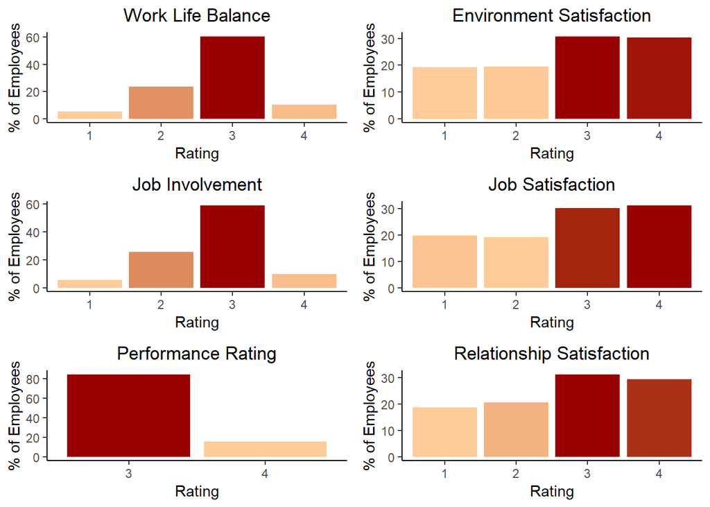

```r
#bar plot showing ratings of Work Life Balance and percentage of employees for each rating
plot1 <- ggplot(data = empdata.WorkLifeBal, aes(x = empdata.WorkLifeBal$WorkLifeBal, y = empdata.WorkLifeBal$percent, fill = empdata.WorkLifeBal$percent)) +
  geom_bar(stat="identity") + scale_fill_gradient(low = "#FFCC99", high = "#990000") + guides(fill=FALSE) +
  labs(title="Work Life Balance") + xlab("Rating") + ylab("% of Employees")  +
  theme(plot.title = element_text(hjust=0.5), panel.background = element_blank())

#bar plot showing ratings of Environment Satisfaction and percentage of employees for each rating
plot2 <- ggplot(data = empdata.EnvirSatisf, aes(x = empdata.EnvirSatisf$EnvirSatisf, y = empdata.EnvirSatisf$percent, fill = empdata.EnvirSatisf$percent)) +
  geom_bar(stat="identity") + scale_fill_gradient(low = "#FFCC99", high = "#990000") + guides(fill=FALSE) +
  labs( title="Environment Satisfaction") + xlab("Rating") + ylab("% of Employees")  +
  theme( plot.title = element_text(hjust=0.5), panel.background = element_blank())

#bar plot showing ratings of Job Involvement and percentage of employees for each rating
plot3 <- ggplot(data = empdata.JobInvolvmnt, aes(x = empdata.JobInvolvmnt$JobInvolvmnt, y = empdata.JobInvolvmnt$percent, fill = empdata.JobInvolvmnt$percent)) +
  geom_bar(stat="identity") + scale_fill_gradient(low = "#FFCC99", high = "#990000") + guides(fill=FALSE) +
  labs( title="Job Involvement") + xlab("Rating") + ylab("% of Employees")  +
  theme( plot.title = element_text(hjust=0.5), panel.background = element_blank())

#bar plot showing ratings of Job Satisfaction and percentage of employees for each rating
plot4 <- ggplot(data = empdata.JobSatisf, aes(x = empdata.JobSatisf$JobSatisf, y = empdata.JobSatisf$percent, fill = empdata.JobSatisf$percent)) +
  geom_bar(stat="identity") + scale_fill_gradient(low = "#FFCC99", high = "#990000") + guides(fill=FALSE) +
  labs( title="Job Satisfaction") + xlab("Rating") + ylab("% of Employees")  +
  theme( plot.title = element_text(hjust=0.5), panel.background = element_blank())

#bar plot showing ratings of Performance Rating and percentage of employees for each rating
plot5 <- ggplot(data = empdata.PerforRating, aes(x = empdata.PerforRating$PerforRating, y = empdata.PerforRating$percent, fill = empdata.PerforRating$percent)) +
  geom_bar(stat="identity") + scale_fill_gradient(low = "#FFCC99", high = "#990000") + guides(fill=FALSE) +
  labs( title="Performance Rating") + xlab("Rating") + ylab("% of Employees")  +
  theme( plot.title = element_text(hjust=0.5), panel.background = element_blank())

#bar plot showing ratings of Work Relationship Satisfaction and percentage of employees for each rating
plot6 <- ggplot(data = empdata.RelshipSatis, aes(x = empdata.RelshipSatis$RelshipSatis, y = empdata.RelshipSatis$percent, fill = empdata.RelshipSatis$percent)) +
  geom_bar(stat="identity") + scale_fill_gradient(low = "#FFCC99", high = "#990000") + guides(fill=FALSE) +
  labs( title="Relationship Satisfaction") + xlab("Rating") + ylab("% of Employees")  +
  theme( plot.title = element_text(hjust=0.5), panel.background = element_blank())

#display all 6 plots together
grid.arrange(plot1, plot2, plot3, plot4, plot5, plot6, ncol=2, nrow=3)
```

### Summary - Insights for Top-Performers in Three Key Departments The Overall FY2017 attrition rate will undoubtedly damage TARA if it continues. The top three contributors to attrition based on this dataset are Over Time, Stock Option Level and Environment Satisfaction.

1. With regards to Over Time, the three Over Time roles with the largest number of employees are Sales Executive, Research Scientist and Laboratory Technician. In general, there is a risk of employee burnout in Over Time roles.
2. Where Stock Option Level is concerned, approximately 65% of those employees who left the company had Stock Option Level 0. We have determined that there seems to be no correlation between Stock Option Level and number of years with TARA or job level.
3. About 30% of employees who left had a low level response rating with regards to the Environment Satisfaction survey question. While this number may seem low it could become significant based on potential longer term impact on employee morale, and should not be disregarded.

Exploring Income and Age, we saw that the two are related overall, with income growing initially along with age, and gradually declining in later years. Income for males exceeds income for females.

Work-Life Satisfaction, while more difficult to quantify, is nonetheless important. Most top performers used one of the top two ratings for Satisfaction-related survey responses, with the majority of average response ratings landing close to each median.

### Summary - Recommendation

DDS Analytics makes the following recommendations:

1. Consider revising Stock Option Level 0 plans
2. Engage employees in a regular basis
1. Request employee feedback for immediate supervisor to improve relationship
2. Hold more frequent employee appreciation activities
3. Create periodic team building activities
3. Consider that equal compensation is extremely important to women evaluating job opportunities when TARA extends job offers.
4. Closely monitor how much over time is being accrued, by which employees and why, with the goal of avoiding employee burnout and enhancing the work environment.

### Summary - Analysis Improvements

DDS Analytics suggest the following analysis improvements:

1. Utilize more advanced modeling techniques, such as random forest for prediction, and baruto for variable importance, which is built on random forest method.
2. Model Job Satisfaction and Relationship Satisfaction within Attrition, as done in the proof-of-concept analysis with Stop Option Level and Environment Satisfaction.